# Week 10.2 Assignment

- Joshua Burden
- Bellevue University
- DSC550 Data Mining
- Dr. Brett Werner
- 11/06/2022

## Begin Milestone 1 with a 250-500-word narrative describing your original idea for the analysis/model building business problem.

## Clearly identify the problem you will address and the target for your model.

#### Background:

During the pandemic an increase in the need for health care professionals was required. The dataset collected is a modified synthetic dataset from IBM's Watson to show a useful insight into the attrition rate for healthcare workers.

#### Problem:

The data set includes information about the attrition rate for employees within the healthcare field. The meaning of employee attrition is the departure of employees from the organization for any reason whether that be voluntary or involuntary, including resignation, termination, death, or retirement. Companies to avoid attrition rates being too high is to replace those who are either leaving voluntarily or involuntary. The data set should provide insights into whether a company in the healthcare field was replacing their employees that were leaving the field, or if they continued to have a gradual but deliberate reduction in staff for any reason.

#### Original Idea:

The idea behind this data set is to discover whether certain roles within the healthcare industry, hours worked, age of an employee, or any other qualifying data points stand out as to why the healthcare industry had any determining factor on whether a person was to leave their field, while also predicting whether the employee was eventually replaced.

#### Dataset:

This dataset contains employee and company data useful for supervised ML, unsupervised ML, and analytics. Attrition - whether an employee left or not - is included and can be used as the target variable. The data is synthetic and based on the IBM Watson dataset for attrition. Employee roles and departments were changed to reflect the healthcare domain. Also, known outcomes for some employees were changed to help increase the performance of ML models

#### Then, do a graphical analysis creating a minimum of four graphs.

#### Label your graphs appropriately and explain/analyze the information provided by each graph.

```python
import pandas as pd
import seaborn as sns
from matplotlib import pyplot as plt
import numpy as np
import plotly.express as px
```

```python
data_df = pd.read_csv('./DATA/watson_healthcare_modified.csv')
data_df.head()
```

|  | EmployeeID | Age | Attrition | BusinessTravel | DailyRate | Department | DistanceFromHome | Education | EducationField | EmployeeCount | ... | RelationshipSatisfaction | StandardHours | Shift | TotalWorkingYears | TrainingTimesLastYear | WorkLifeBalance | YearsAtCompany | YearsInCurrentRole | YearsSinceLastPromotion | YearsWithCurrManager |
| --- | --- | --- | --- | --- | --- | --- | --- | --- | --- | --- | --- | --- | --- | --- | --- | --- | --- | --- | --- | --- | --- |
| 0 | 1313919 | 41 | No | Travel_Rarely | 1102 | Cardiology | 1 | 2 | Life Sciences | 1 | ... | 1 | 80 | 0 | 8 | 0 | 1 | 6 | 4 | 0 | 5 |
| 1 | 1200302 | 49 | No | Travel_Frequently | 279 | Maternity | 8 | 1 | Life Sciences | 1 | ... | 4 | 80 | 1 | 10 | 3 | 3 | 10 | 7 | 1 | 7 |
| 2 | 1060315 | 37 | Yes | Travel_Rarely | 1373 | Maternity | 2 | 2 | Other | 1 | ... | 2 | 80 | 0 | 7 | 3 | 3 | 0 | 0 | 0 | 0 |
| 3 | 1272912 | 33 | No | Travel_Frequently | 1392 | Maternity | 3 | 4 | Life Sciences | 1 | ... | 3 | 80 | 0 | 8 | 3 | 3 | 8 | 7 | 3 | 0 |
| 4 | 1414939 | 27 | No | Travel_Rarely | 591 | Maternity | 2 | 1 | Medical | 1 | ... | 4 | 80 | 1 | 6 | 3 | 3 | 2 | 2 | 2 | 2 |

5 rows × 35 columns

```python
print("Number of duplicated data: "+str(data_df.duplicated().sum()))
```

```
Number of duplicated data: 0
```

```python
data_df.isnull().sum()
```

```
EmployeeID                  0
Age                         0
Attrition                   0
BusinessTravel              0
DailyRate                   0
Department                  0
DistanceFromHome            0
Education                   0
EducationField              0
EmployeeCount               0
EnvironmentSatisfaction     0
Gender                      0
HourlyRate                  0
JobInvolvement              0
JobLevel                    0
JobRole                     0
JobSatisfaction             0
MaritalStatus               0
MonthlyIncome               0
MonthlyRate                 0
NumCompaniesWorked          0
Over18                      0
OverTime                    0
PercentSalaryHike           0
PerformanceRating           0
RelationshipSatisfaction    0
StandardHours               0
Shift                       0
TotalWorkingYears           0
TrainingTimesLastYear       0
WorkLifeBalance             0
YearsAtCompany              0
YearsInCurrentRole          0
YearsSinceLastPromotion     0
YearsWithCurrManager        0
dtype: int64
```

```python
data_df.info()
```

```
<class 'pandas.core.frame.DataFrame'>
RangeIndex: 1676 entries, 0 to 1675
Data columns (total 35 columns):
 #   Column                    Non-Null Count  Dtype
---  ------                    --------------  -----
 0   EmployeeID                1676 non-null   int64
 1   Age                       1676 non-null   int64
 2   Attrition                 1676 non-null   object
 3   BusinessTravel            1676 non-null   object
 4   DailyRate                 1676 non-null   int64
 5   Department                1676 non-null   object
 6   DistanceFromHome          1676 non-null   int64
 7   Education                 1676 non-null   int64
 8   EducationField            1676 non-null   object
 9   EmployeeCount             1676 non-null   int64
```

[output cut: 27 more lines]

### Visualization 1

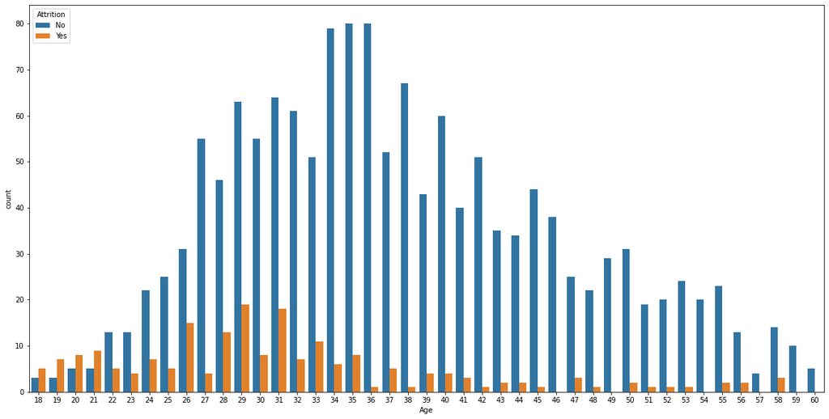

```python
plt.figure(figsize=(20,10))
sns.countplot(x='Age',hue='Attrition',data=data_df)
```

### Visualization 2

```python
data_df.groupby('Attrition')['MonthlyIncome'].mean().sort_values().reset_index()
```

|  | Attrition | MonthlyIncome |
| --- | --- | --- |
| 0 | Yes | 4024.246231 |
| 1 | No | 6852.301963 |

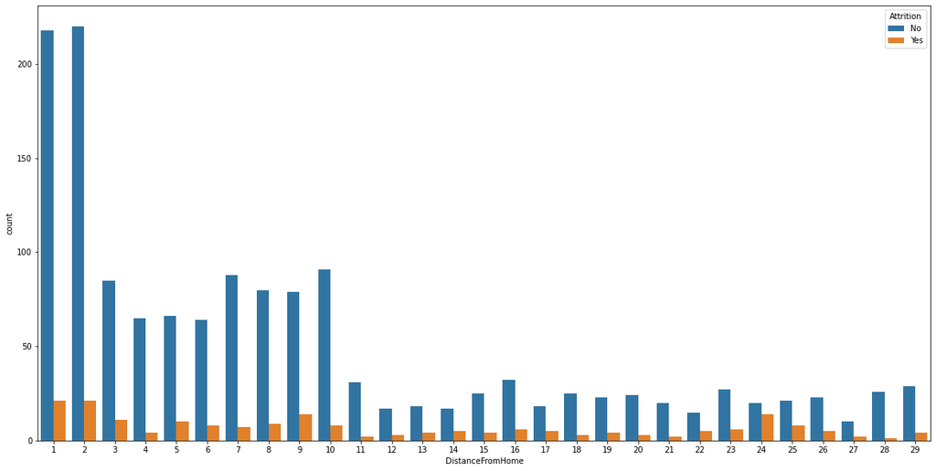

```python
plt.figure(figsize=(20,10))
sns.countplot(x='DistanceFromHome',hue='Attrition',data=data_df)
```

### Visualization 3

```python
px.histogram(data_df,x="Department",color="Attrition",barmode="group",text_auto=".2f",template="plotly_dark",
             title = "Percentage of Department Type")
```

```python
px.histogram(data_df,x="EducationField",color="Attrition",barmode="group",text_auto=".2f",template="plotly_dark",
             title = "Percentage of EducationField Type")
```

```python
px.histogram(data_df,x="JobRole",color="Attrition",barmode="group",text_auto=".2f",template="plotly_dark",
             title = "Percentage of EducationField Type")
```

### Visualization 4

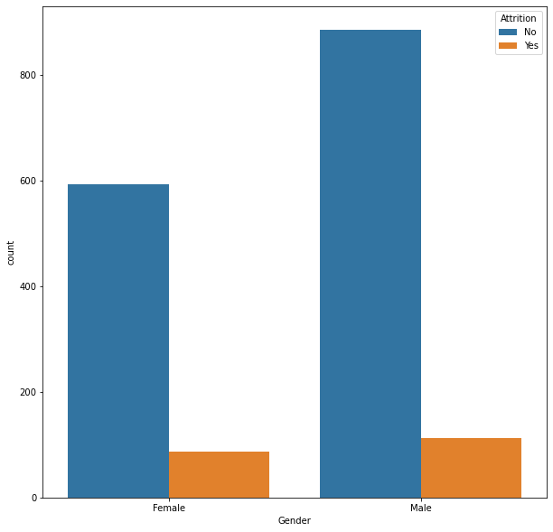

```python
plt.figure(figsize=(10,10))
sns.countplot(x='Gender',hue='Attrition',data=data_df)
```

#### Breakdown of all the available datapoints

```python
plt.figure(figsize=(30,50))
for index,column in enumerate(num_col):
    plt.subplot(5,5,index+1)
    sns.countplot(data=num_col,x=column)
    plt.xticks(rotation = 90)
plt.tight_layout(pad = 1.0)
plt.show()
```

[output not shown]

### Observations:

# Milestone 2

```python
data_df.head()
```

|  | EmployeeID | Age | Attrition | BusinessTravel | DailyRate | Department | DistanceFromHome | Education | EducationField | EmployeeCount | ... | RelationshipSatisfaction | StandardHours | Shift | TotalWorkingYears | TrainingTimesLastYear | WorkLifeBalance | YearsAtCompany | YearsInCurrentRole | YearsSinceLastPromotion | YearsWithCurrManager |
| --- | --- | --- | --- | --- | --- | --- | --- | --- | --- | --- | --- | --- | --- | --- | --- | --- | --- | --- | --- | --- | --- |
| 0 | 1313919 | 41 | No | Travel_Rarely | 1102 | Cardiology | 1 | 2 | Life Sciences | 1 | ... | 1 | 80 | 0 | 8 | 0 | 1 | 6 | 4 | 0 | 5 |
| 1 | 1200302 | 49 | No | Travel_Frequently | 279 | Maternity | 8 | 1 | Life Sciences | 1 | ... | 4 | 80 | 1 | 10 | 3 | 3 | 10 | 7 | 1 | 7 |
| 2 | 1060315 | 37 | Yes | Travel_Rarely | 1373 | Maternity | 2 | 2 | Other | 1 | ... | 2 | 80 | 0 | 7 | 3 | 3 | 0 | 0 | 0 | 0 |
| 3 | 1272912 | 33 | No | Travel_Frequently | 1392 | Maternity | 3 | 4 | Life Sciences | 1 | ... | 3 | 80 | 0 | 8 | 3 | 3 | 8 | 7 | 3 | 0 |
| 4 | 1414939 | 27 | No | Travel_Rarely | 591 | Maternity | 2 | 1 | Medical | 1 | ... | 4 | 80 | 1 | 6 | 3 | 3 | 2 | 2 | 2 | 2 |

5 rows × 35 columns

```python
data_df.shape
```

```
(1676, 35)
```

Dropping data columns that don't provide much value or context to the data

```python
#drop some of the values
data_df1 = data_df.drop(['EmployeeID','Over18', 'EmployeeCount', 'StandardHours'], axis=1)
data_df1.head()
```

|  | Age | Attrition | BusinessTravel | DailyRate | Department | DistanceFromHome | Education | EducationField | EnvironmentSatisfaction | Gender | ... | PerformanceRating | RelationshipSatisfaction | Shift | TotalWorkingYears | TrainingTimesLastYear | WorkLifeBalance | YearsAtCompany | YearsInCurrentRole | YearsSinceLastPromotion | YearsWithCurrManager |
| --- | --- | --- | --- | --- | --- | --- | --- | --- | --- | --- | --- | --- | --- | --- | --- | --- | --- | --- | --- | --- | --- |
| 0 | 41 | No | Travel_Rarely | 1102 | Cardiology | 1 | 2 | Life Sciences | 2 | Female | ... | 3 | 1 | 0 | 8 | 0 | 1 | 6 | 4 | 0 | 5 |
| 1 | 49 | No | Travel_Frequently | 279 | Maternity | 8 | 1 | Life Sciences | 3 | Male | ... | 4 | 4 | 1 | 10 | 3 | 3 | 10 | 7 | 1 | 7 |
| 2 | 37 | Yes | Travel_Rarely | 1373 | Maternity | 2 | 2 | Other | 4 | Male | ... | 3 | 2 | 0 | 7 | 3 | 3 | 0 | 0 | 0 | 0 |
| 3 | 33 | No | Travel_Frequently | 1392 | Maternity | 3 | 4 | Life Sciences | 4 | Female | ... | 3 | 3 | 0 | 8 | 3 | 3 | 8 | 7 | 3 | 0 |
| 4 | 27 | No | Travel_Rarely | 591 | Maternity | 2 | 1 | Medical | 1 | Male | ... | 3 | 4 | 1 | 6 | 3 | 3 | 2 | 2 | 2 | 2 |

5 rows × 31 columns

```python
#change attrition rates from no/yes to 0/1
data_df1['Attrition'] = data_df1['Attrition'].str.replace('Yes', str(1))
data_df1['Attrition'] = data_df1['Attrition'].str.replace('No', str(0))
data_df1['Attrition'] = data_df1['Attrition'].astype('int')
```

converted attriations yes/no values and replaced them with 0/1 and set type to int

Look at shape and values of columns

```python
data_df1.head()
```

|  | Age | Attrition | BusinessTravel | DailyRate | Department | DistanceFromHome | Education | EducationField | EnvironmentSatisfaction | Gender | ... | PerformanceRating | RelationshipSatisfaction | Shift | TotalWorkingYears | TrainingTimesLastYear | WorkLifeBalance | YearsAtCompany | YearsInCurrentRole | YearsSinceLastPromotion | YearsWithCurrManager |
| --- | --- | --- | --- | --- | --- | --- | --- | --- | --- | --- | --- | --- | --- | --- | --- | --- | --- | --- | --- | --- | --- |
| 0 | 41 | 0 | Travel_Rarely | 1102 | Cardiology | 1 | 2 | Life Sciences | 2 | Female | ... | 3 | 1 | 0 | 8 | 0 | 1 | 6 | 4 | 0 | 5 |
| 1 | 49 | 0 | Travel_Frequently | 279 | Maternity | 8 | 1 | Life Sciences | 3 | Male | ... | 4 | 4 | 1 | 10 | 3 | 3 | 10 | 7 | 1 | 7 |
| 2 | 37 | 1 | Travel_Rarely | 1373 | Maternity | 2 | 2 | Other | 4 | Male | ... | 3 | 2 | 0 | 7 | 3 | 3 | 0 | 0 | 0 | 0 |
| 3 | 33 | 0 | Travel_Frequently | 1392 | Maternity | 3 | 4 | Life Sciences | 4 | Female | ... | 3 | 3 | 0 | 8 | 3 | 3 | 8 | 7 | 3 | 0 |
| 4 | 27 | 0 | Travel_Rarely | 591 | Maternity | 2 | 1 | Medical | 1 | Male | ... | 3 | 4 | 1 | 6 | 3 | 3 | 2 | 2 | 2 | 2 |

5 rows × 31 columns

```python
data_df1.describe().T
```

|  | count | mean | std | min | 25% | 50% | 75% | max |
| --- | --- | --- | --- | --- | --- | --- | --- | --- |
| Age | 1676.0 | 36.866348 | 9.129126 | 18.0 | 30.00 | 36.0 | 43.00 | 60.0 |
| Attrition | 1676.0 | 0.118735 | 0.323573 | 0.0 | 0.00 | 0.0 | 0.00 | 1.0 |
| DailyRate | 1676.0 | 800.557876 | 401.594438 | 102.0 | 465.00 | 796.5 | 1157.00 | 1499.0 |
| DistanceFromHome | 1676.0 | 9.221957 | 8.158118 | 1.0 | 2.00 | 7.0 | 14.00 | 29.0 |
| Education | 1676.0 | 2.907518 | 1.025835 | 1.0 | 2.00 | 3.0 | 4.00 | 5.0 |
| EnvironmentSatisfaction | 1676.0 | 2.714797 | 1.097534 | 1.0 | 2.00 | 3.0 | 4.00 | 4.0 |
| HourlyRate | 1676.0 | 65.470167 | 20.207572 | 30.0 | 48.00 | 65.5 | 83.00 | 100.0 |
| JobInvolvement | 1676.0 | 2.724940 | 0.714121 | 1.0 | 2.00 | 3.0 | 3.00 | 4.0 |
| JobLevel | 1676.0 | 2.066826 | 1.113423 | 1.0 | 1.00 | 2.0 | 3.00 | 5.0 |
| JobSatisfaction | 1676.0 | 2.738663 | 1.104005 | 1.0 | 2.00 | 3.0 | 4.00 | 4.0 |
| MonthlyIncome | 1676.0 | 6516.512530 | 4728.456618 | 1009.0 | 2928.25 | 4899.0 | 8380.25 | 19999.0 |
| MonthlyRate | 1676.0 | 14287.019690 | 7138.857783 | 2094.0 | 7993.00 | 14269.5 | 20462.00 | 26999.0 |
| NumCompaniesWorked | 1676.0 | 2.662291 | 2.477704 | 0.0 | 1.00 | 2.0 | 4.00 | 9.0 |
| PercentSalaryHike | 1676.0 | 15.196897 | 3.646550 | 11.0 | 12.00 | 14.0 | 18.00 | 25.0 |
| PerformanceRating | 1676.0 | 3.150358 | 0.357529 | 3.0 | 3.00 | 3.0 | 3.00 | 4.0 |
| RelationshipSatisfaction | 1676.0 | 2.718377 | 1.078162 | 1.0 | 2.00 | 3.0 | 4.00 | 4.0 |
| Shift | 1676.0 | 0.806086 | 0.855527 | 0.0 | 0.00 | 1.0 | 1.00 | 3.0 |
| TotalWorkingYears | 1676.0 | 11.338902 | 7.834996 | 0.0 | 6.00 | 10.0 | 15.00 | 40.0 |
| TrainingTimesLastYear | 1676.0 | 2.805489 | 1.288431 | 0.0 | 2.00 | 3.0 | 3.00 | 6.0 |
| WorkLifeBalance | 1676.0 | 2.766110 | 0.702369 | 1.0 | 2.00 | 3.0 | 3.00 | 4.0 |
| YearsAtCompany | 1676.0 | 7.033413 | 6.098991 | 0.0 | 3.00 | 5.0 | 10.00 | 40.0 |
| YearsInCurrentRole | 1676.0 | 4.264916 | 3.627456 | 0.0 | 2.00 | 3.0 | 7.00 | 18.0 |
| YearsSinceLastPromotion | 1676.0 | 2.200477 | 3.229587 | 0.0 | 0.00 | 1.0 | 3.00 | 15.0 |
| YearsWithCurrManager | 1676.0 | 4.135442 | 3.559662 | 0.0 | 2.00 | 3.0 | 7.00 | 17.0 |

check correlation of data columns

```python
data_df1.corr()
```

|  | Age | Attrition | DailyRate | DistanceFromHome | Education | EnvironmentSatisfaction | HourlyRate | JobInvolvement | JobLevel | JobSatisfaction | ... | PerformanceRating | RelationshipSatisfaction | Shift | TotalWorkingYears | TrainingTimesLastYear | WorkLifeBalance | YearsAtCompany | YearsInCurrentRole | YearsSinceLastPromotion | YearsWithCurrManager |
| --- | --- | --- | --- | --- | --- | --- | --- | --- | --- | --- | --- | --- | --- | --- | --- | --- | --- | --- | --- | --- | --- |
| Age | 1.000000 | -0.239984 | 0.001441 | -0.010079 | 0.204655 | 0.008945 | 0.034671 | 0.034193 | 0.518333 | -0.015848 | ... | 0.005246 | 0.058528 | 0.037117 | 0.692512 | -0.015408 | -0.004878 | 0.319012 | 0.222655 | 0.217212 | 0.215909 |
| Attrition | -0.239984 | 1.000000 | -0.053892 | 0.105580 | -0.038843 | -0.101278 | -0.036300 | -0.166036 | -0.207634 | -0.081881 | ... | 0.010728 | -0.020462 | -0.158322 | -0.234182 | -0.054836 | -0.090513 | -0.201373 | -0.207891 | -0.086207 | -0.201087 |
| DailyRate | 0.001441 | -0.053892 | 1.000000 | -0.009227 | -0.015881 | 0.010620 | 0.027128 | 0.058864 | 0.009005 | 0.032115 | ... | 0.003353 | 0.014539 | 0.054407 | 0.009378 | 0.001901 | -0.028549 | -0.026892 | 0.019651 | -0.034571 | -0.025272 |
| DistanceFromHome | -0.010079 | 0.105580 | -0.009227 | 1.000000 | 0.015937 | -0.019730 | 0.026947 | 0.010281 | -0.023455 | -0.004758 | ... | 0.020482 | 0.005482 | 0.029180 | -0.017663 | -0.055471 | -0.037821 | -0.007420 | 0.011448 | -0.000126 | 0.000403 |
| Education | 0.204655 | -0.038843 | -0.015881 | 0.015937 | 1.000000 | -0.031925 | 0.017996 | 0.041046 | 0.093227 | -0.003957 | ... | -0.020664 | -0.005750 | 0.024451 | 0.143324 | -0.014070 | 0.003933 | 0.057461 | 0.051029 | 0.045785 | 0.055096 |
| EnvironmentSatisfaction | 0.008945 | -0.101278 | 0.010620 | -0.019730 | -0.031925 | 1.000000 | -0.057505 | -0.007220 | 0.008277 | 0.001518 | ... | -0.029104 | 0.003221 | 0.005283 | 0.000208 | -0.017722 | 0.027262 | -0.000448 | 0.012241 | 0.005866 | -0.012417 |
| HourlyRate | 0.034671 | -0.036300 | 0.027128 | 0.026947 | 0.017996 | -0.057505 | 1.000000 | 0.034741 | -0.018830 | -0.073942 | ... | -0.000370 | 0.000601 | 0.051862 | 0.005988 | -0.007194 | -0.009956 | -0.014742 | -0.016776 | -0.028642 | -0.021436 |
| JobInvolvement | 0.034193 | -0.166036 | 0.058864 | 0.010281 | 0.041046 | -0.007220 | 0.034741 | 1.000000 | -0.013660 | -0.039738 | ... | -0.017970 | 0.045107 | 0.025999 | -0.001576 | -0.031580 | -0.006931 | -0.013652 | 0.020541 | -0.022153 | 0.031574 |
| JobLevel | 0.518333 | -0.207634 | 0.009005 | -0.023455 | 0.093227 | 0.008277 | -0.018830 | -0.013660 | 1.000000 | -0.012497 | ... | -0.008759 | 0.030606 | 0.010478 | 0.780929 | -0.004251 | 0.047481 | 0.532529 | 0.387624 | 0.343102 | 0.379717 |
| JobSatisfaction | -0.015848 | -0.081881 | 0.032115 | -0.004758 | -0.003957 | 0.001518 | -0.073942 | -0.039738 | -0.012497 | 1.000000 | ... | 0.008859 | -0.018232 | 0.017740 | -0.021435 | -0.003440 | -0.017280 | 0.005376 | -0.001337 | -0.013595 | -0.023042 |
| MonthlyIncome | 0.511378 | -0.193527 | 0.011030 | -0.041201 | 0.085116 | 0.003372 | -0.008443 | -0.019240 | 0.951572 | -0.016550 | ... | -0.005113 | 0.033035 | 0.005847 | 0.772938 | -0.009690 | 0.039910 | 0.513977 | 0.364152 | 0.337241 | 0.350122 |
| MonthlyRate | 0.025837 | 0.045744 | -0.032211 | 0.031672 | -0.019198 | 0.046771 | -0.025597 | -0.018490 | 0.036901 | 0.006244 | ... | -0.025382 | -0.015690 | -0.040083 | 0.023876 | 0.002747 | 0.002448 | -0.032950 | -0.022279 | -0.013589 | -0.053408 |
| NumCompaniesWorked | 0.296045 | 0.017279 | 0.034296 | -0.024969 | 0.126758 | 0.012640 | 0.029132 | 0.016303 | 0.153179 | -0.067204 | ... | -0.018801 | 0.063381 | 0.023164 | 0.250514 | -0.056122 | -0.005620 | -0.108807 | -0.080578 | -0.025033 | -0.093030 |
| PercentSalaryHike | 0.007570 | 0.002943 | 0.019325 | 0.034172 | -0.006461 | -0.021612 | -0.013240 | -0.019999 | -0.024711 | 0.035775 | ... | 0.766737 | -0.034936 | 0.017987 | -0.010131 | -0.029329 | -0.010680 | -0.022281 | 0.010046 | -0.000870 | -0.004769 |
| PerformanceRating | 0.005246 | 0.010728 | 0.003353 | 0.020482 | -0.020664 | -0.029104 | -0.000370 | -0.017970 | -0.008759 | 0.008859 | ... | 1.000000 | -0.027926 | 0.007546 | 0.014407 | -0.036267 | -0.004897 | 0.016586 | 0.048446 | 0.037992 | 0.031837 |
| RelationshipSatisfaction | 0.058528 | -0.020462 | 0.014539 | 0.005482 | -0.005750 | 0.003221 | 0.000601 | 0.045107 | 0.030606 | -0.018232 | ... | -0.027926 | 1.000000 | -0.042412 | 0.029257 | 0.003090 | 0.012302 | 0.022223 | -0.014648 | 0.040914 | 0.003256 |
| Shift | 0.037117 | -0.158322 | 0.054407 | 0.029180 | 0.024451 | 0.005283 | 0.051862 | 0.025999 | 0.010478 | 0.017740 | ... | 0.007546 | -0.042412 | 1.000000 | 0.009632 | 0.025881 | -0.001008 | 0.013028 | 0.039263 | 0.011702 | 0.014314 |
| TotalWorkingYears | 0.692512 | -0.234182 | 0.009378 | -0.017663 | 0.143324 | 0.000208 | 0.005988 | -0.001576 | 0.780929 | -0.021435 | ... | 0.014407 | 0.029257 | 0.009632 | 1.000000 | -0.026171 | 0.012677 | 0.622495 | 0.457439 | 0.394941 | 0.461688 |
| TrainingTimesLastYear | -0.015408 | -0.054836 | 0.001901 | -0.055471 | -0.014070 | -0.017722 | -0.007194 | -0.031580 | -0.004251 | -0.003440 | ... | -0.036267 | 0.003090 | 0.025881 | -0.026171 | 1.000000 | 0.033482 | 0.001739 | -0.007362 | -0.008844 | -0.005057 |
| WorkLifeBalance | -0.004878 | -0.090513 | -0.028549 | -0.037821 | 0.003933 | 0.027262 | -0.009956 | -0.006931 | 0.047481 | -0.017280 | ... | -0.004897 | 0.012302 | -0.001008 | 0.012677 | 0.033482 | 1.000000 | 0.011721 | 0.046360 | 0.013051 | 0.005276 |
| YearsAtCompany | 0.319012 | -0.201373 | -0.026892 | -0.007420 | 0.057461 | -0.000448 | -0.014742 | -0.013652 | 0.532529 | 0.005376 | ... | 0.016586 | 0.022223 | 0.013028 | 0.622495 | 0.001739 | 0.011721 | 1.000000 | 0.759421 | 0.616915 | 0.771224 |
| YearsInCurrentRole | 0.222655 | -0.207891 | 0.019651 | 0.011448 | 0.051029 | 0.012241 | -0.016776 | 0.020541 | 0.387624 | -0.001337 | ... | 0.048446 | -0.014648 | 0.039263 | 0.457439 | -0.007362 | 0.046360 | 0.759421 | 1.000000 | 0.548235 | 0.721543 |
| YearsSinceLastPromotion | 0.217212 | -0.086207 | -0.034571 | -0.000126 | 0.045785 | 0.005866 | -0.028642 | -0.022153 | 0.343102 | -0.013595 | ... | 0.037992 | 0.040914 | 0.011702 | 0.394941 | -0.008844 | 0.013051 | 0.616915 | 0.548235 | 1.000000 | 0.518664 |
| YearsWithCurrManager | 0.215909 | -0.201087 | -0.025272 | 0.000403 | 0.055096 | -0.012417 | -0.021436 | 0.031574 | 0.379717 | -0.023042 | ... | 0.031837 | 0.003256 | 0.014314 | 0.461688 | -0.005057 | 0.005276 | 0.771224 | 0.721543 | 0.518664 | 1.000000 |

24 rows × 24 columns

```python
threshold = 0.2
data_df1 = data_df1.drop(data_df1.std()[data_df1.std() < threshold].index.values, axis=1)
```

```python
data_df1
```

|  | Age | Attrition | BusinessTravel | DailyRate | Department | DistanceFromHome | Education | EducationField | EnvironmentSatisfaction | Gender | ... | PerformanceRating | RelationshipSatisfaction | Shift | TotalWorkingYears | TrainingTimesLastYear | WorkLifeBalance | YearsAtCompany | YearsInCurrentRole | YearsSinceLastPromotion | YearsWithCurrManager |
| --- | --- | --- | --- | --- | --- | --- | --- | --- | --- | --- | --- | --- | --- | --- | --- | --- | --- | --- | --- | --- | --- |
| 0 | 41 | 0 | Travel_Rarely | 1102 | Cardiology | 1 | 2 | Life Sciences | 2 | Female | ... | 3 | 1 | 0 | 8 | 0 | 1 | 6 | 4 | 0 | 5 |
| 1 | 49 | 0 | Travel_Frequently | 279 | Maternity | 8 | 1 | Life Sciences | 3 | Male | ... | 4 | 4 | 1 | 10 | 3 | 3 | 10 | 7 | 1 | 7 |
| 2 | 37 | 1 | Travel_Rarely | 1373 | Maternity | 2 | 2 | Other | 4 | Male | ... | 3 | 2 | 0 | 7 | 3 | 3 | 0 | 0 | 0 | 0 |
| 3 | 33 | 0 | Travel_Frequently | 1392 | Maternity | 3 | 4 | Life Sciences | 4 | Female | ... | 3 | 3 | 0 | 8 | 3 | 3 | 8 | 7 | 3 | 0 |
| 4 | 27 | 0 | Travel_Rarely | 591 | Maternity | 2 | 1 | Medical | 1 | Male | ... | 3 | 4 | 1 | 6 | 3 | 3 | 2 | 2 | 2 | 2 |
| ... | ... | ... | ... | ... | ... | ... | ... | ... | ... | ... | ... | ... | ... | ... | ... | ... | ... | ... | ... | ... | ... |
| 1671 | 26 | 1 | Travel_Rarely | 471 | Neurology | 24 | 3 | Technical Degree | 3 | Male | ... | 3 | 2 | 0 | 1 | 3 | 1 | 1 | 0 | 0 | 0 |
| 1672 | 46 | 0 | Travel_Rarely | 1125 | Cardiology | 10 | 3 | Marketing | 3 | Female | ... | 3 | 3 | 1 | 15 | 3 | 3 | 3 | 2 | 1 | 2 |
| 1673 | 20 | 0 | Travel_Rarely | 959 | Maternity | 1 | 3 | Life Sciences | 4 | Female | ... | 3 | 4 | 0 | 1 | 0 | 4 | 1 | 0 | 0 | 0 |
| 1674 | 39 | 0 | Travel_Rarely | 466 | Neurology | 1 | 1 | Life Sciences | 4 | Female | ... | 3 | 3 | 1 | 21 | 3 | 3 | 21 | 6 | 11 | 8 |
| 1675 | 27 | 0 | Travel_Rarely | 511 | Cardiology | 2 | 2 | Medical | 1 | Female | ... | 3 | 2 | 0 | 9 | 5 | 2 | 8 | 7 | 0 | 7 |

1676 rows × 31 columns

```python
#Get dummies
data_df2 = data_df1.copy()
data_df2 = pd.get_dummies(data_df2, drop_first=True)
data_df2
```

|  | Age | Attrition | DailyRate | DistanceFromHome | Education | EnvironmentSatisfaction | HourlyRate | JobInvolvement | JobLevel | JobSatisfaction | ... | EducationField_Other | EducationField_Technical Degree | Gender_Male | JobRole_Administrative | JobRole_Nurse | JobRole_Other | JobRole_Therapist | MaritalStatus_Married | MaritalStatus_Single | OverTime_Yes |
| --- | --- | --- | --- | --- | --- | --- | --- | --- | --- | --- | --- | --- | --- | --- | --- | --- | --- | --- | --- | --- | --- |
| 0 | 41 | 0 | 1102 | 1 | 2 | 2 | 94 | 3 | 2 | 4 | ... | 0 | 0 | 0 | 0 | 1 | 0 | 0 | 0 | 1 | 1 |
| 1 | 49 | 0 | 279 | 8 | 1 | 3 | 61 | 2 | 2 | 2 | ... | 0 | 0 | 1 | 0 | 0 | 1 | 0 | 1 | 0 | 0 |
| 2 | 37 | 1 | 1373 | 2 | 2 | 4 | 92 | 2 | 1 | 3 | ... | 1 | 0 | 1 | 0 | 1 | 0 | 0 | 0 | 1 | 1 |
| 3 | 33 | 0 | 1392 | 3 | 4 | 4 | 56 | 3 | 1 | 3 | ... | 0 | 0 | 0 | 0 | 0 | 1 | 0 | 1 | 0 | 1 |
| 4 | 27 | 0 | 591 | 2 | 1 | 1 | 40 | 3 | 1 | 2 | ... | 0 | 0 | 1 | 0 | 1 | 0 | 0 | 1 | 0 | 0 |
| ... | ... | ... | ... | ... | ... | ... | ... | ... | ... | ... | ... | ... | ... | ... | ... | ... | ... | ... | ... | ... | ... |
| 1671 | 26 | 1 | 471 | 24 | 3 | 3 | 66 | 1 | 1 | 4 | ... | 0 | 1 | 1 | 0 | 1 | 0 | 0 | 0 | 1 | 1 |
| 1672 | 46 | 0 | 1125 | 10 | 3 | 3 | 94 | 2 | 3 | 4 | ... | 0 | 0 | 0 | 0 | 1 | 0 | 0 | 1 | 0 | 1 |
| 1673 | 20 | 0 | 959 | 1 | 3 | 4 | 83 | 2 | 1 | 2 | ... | 0 | 0 | 0 | 0 | 0 | 1 | 0 | 0 | 1 | 0 |
| 1674 | 39 | 0 | 466 | 1 | 1 | 4 | 65 | 2 | 4 | 4 | ... | 0 | 0 | 0 | 0 | 0 | 0 | 1 | 1 | 0 | 0 |
| 1675 | 27 | 0 | 511 | 2 | 2 | 1 | 89 | 4 | 2 | 3 | ... | 0 | 0 | 0 | 0 | 1 | 0 | 0 | 0 | 1 | 0 |

1676 rows × 41 columns

```python
data_df2.info()
```

```
<class 'pandas.core.frame.DataFrame'>
RangeIndex: 1676 entries, 0 to 1675
Data columns (total 41 columns):
 #   Column                            Non-Null Count  Dtype
---  ------                            --------------  -----
 0   Age                               1676 non-null   int64
 1   Attrition                         1676 non-null   int32
 2   DailyRate                         1676 non-null   int64
 3   DistanceFromHome                  1676 non-null   int64
 4   Education                         1676 non-null   int64
 5   EnvironmentSatisfaction           1676 non-null   int64
 6   HourlyRate                        1676 non-null   int64
 7   JobInvolvement                    1676 non-null   int64
 8   JobLevel                          1676 non-null   int64
 9   JobSatisfaction                   1676 non-null   int64
```

[output cut: 33 more lines]

create the final dataframe

```python
df_final = data_df2.copy()
df_final
```

|  | Age | Attrition | DailyRate | DistanceFromHome | Education | EnvironmentSatisfaction | HourlyRate | JobInvolvement | JobLevel | JobSatisfaction | ... | EducationField_Other | EducationField_Technical Degree | Gender_Male | JobRole_Administrative | JobRole_Nurse | JobRole_Other | JobRole_Therapist | MaritalStatus_Married | MaritalStatus_Single | OverTime_Yes |
| --- | --- | --- | --- | --- | --- | --- | --- | --- | --- | --- | --- | --- | --- | --- | --- | --- | --- | --- | --- | --- | --- |
| 0 | 41 | 0 | 1102 | 1 | 2 | 2 | 94 | 3 | 2 | 4 | ... | 0 | 0 | 0 | 0 | 1 | 0 | 0 | 0 | 1 | 1 |
| 1 | 49 | 0 | 279 | 8 | 1 | 3 | 61 | 2 | 2 | 2 | ... | 0 | 0 | 1 | 0 | 0 | 1 | 0 | 1 | 0 | 0 |
| 2 | 37 | 1 | 1373 | 2 | 2 | 4 | 92 | 2 | 1 | 3 | ... | 1 | 0 | 1 | 0 | 1 | 0 | 0 | 0 | 1 | 1 |
| 3 | 33 | 0 | 1392 | 3 | 4 | 4 | 56 | 3 | 1 | 3 | ... | 0 | 0 | 0 | 0 | 0 | 1 | 0 | 1 | 0 | 1 |
| 4 | 27 | 0 | 591 | 2 | 1 | 1 | 40 | 3 | 1 | 2 | ... | 0 | 0 | 1 | 0 | 1 | 0 | 0 | 1 | 0 | 0 |
| ... | ... | ... | ... | ... | ... | ... | ... | ... | ... | ... | ... | ... | ... | ... | ... | ... | ... | ... | ... | ... | ... |
| 1671 | 26 | 1 | 471 | 24 | 3 | 3 | 66 | 1 | 1 | 4 | ... | 0 | 1 | 1 | 0 | 1 | 0 | 0 | 0 | 1 | 1 |
| 1672 | 46 | 0 | 1125 | 10 | 3 | 3 | 94 | 2 | 3 | 4 | ... | 0 | 0 | 0 | 0 | 1 | 0 | 0 | 1 | 0 | 1 |
| 1673 | 20 | 0 | 959 | 1 | 3 | 4 | 83 | 2 | 1 | 2 | ... | 0 | 0 | 0 | 0 | 0 | 1 | 0 | 0 | 1 | 0 |
| 1674 | 39 | 0 | 466 | 1 | 1 | 4 | 65 | 2 | 4 | 4 | ... | 0 | 0 | 0 | 0 | 0 | 0 | 1 | 1 | 0 | 0 |
| 1675 | 27 | 0 | 511 | 2 | 2 | 1 | 89 | 4 | 2 | 3 | ... | 0 | 0 | 0 | 0 | 1 | 0 | 0 | 0 | 1 | 0 |

1676 rows × 41 columns

Create a training and test model set

```python
from sklearn.model_selection import train_test_split
from sklearn.tree import DecisionTreeClassifier
from sklearn import tree
from sklearn.metrics import accuracy_score
from sklearn.metrics import confusion_matrix
```

```python
X = df_final.drop(['Attrition'], axis='columns')
```

```python
y= df_final['Attrition']
y.to_frame().head()
```

|  | Attrition |
| --- | --- |
| 0 | 0 |
| 1 | 0 |
| 2 | 1 |
| 3 | 0 |
| 4 | 0 |

```python
print("X shape",X.shape,"\n","y shape",y.shape)
```

```
X shape (1676, 40)
 y shape (1676,)
```

```python
num_cols = [col for col in data_df.columns if data_df[col].dtypes in ("int64", "float64")]
```

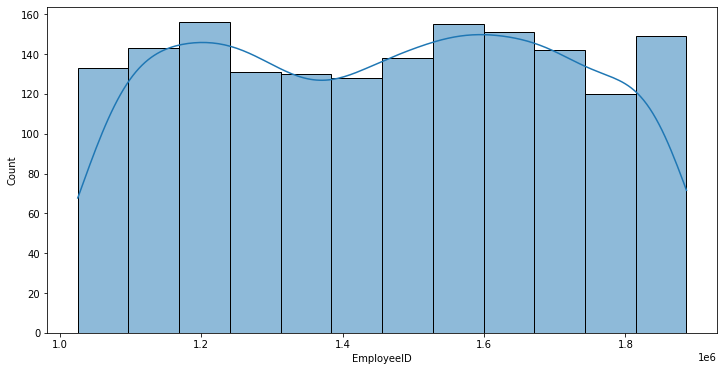

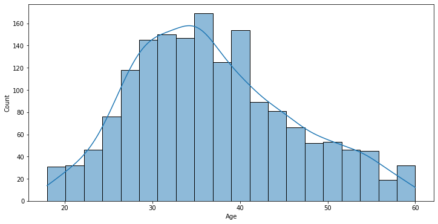

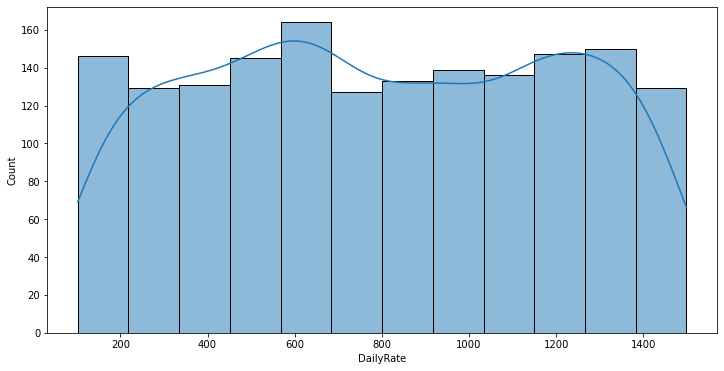

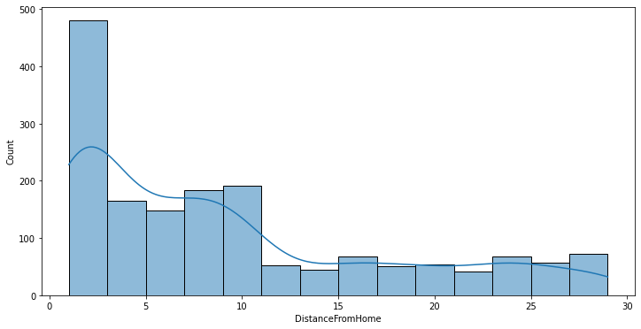

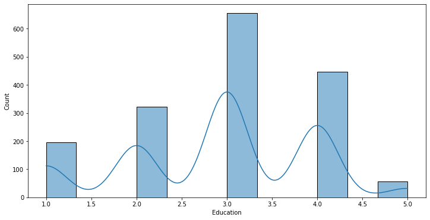

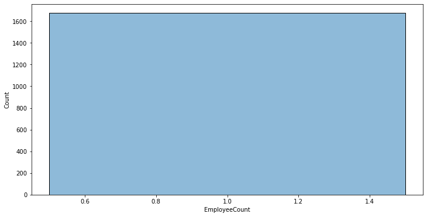

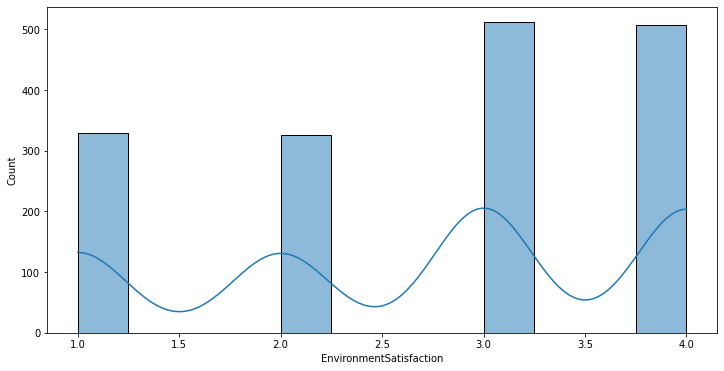

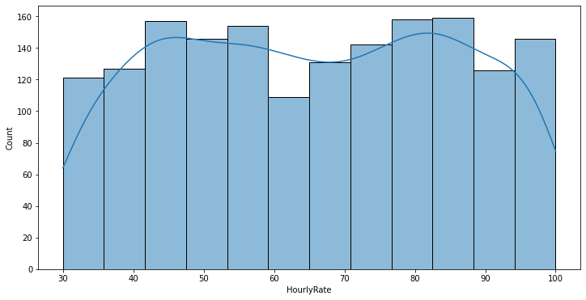

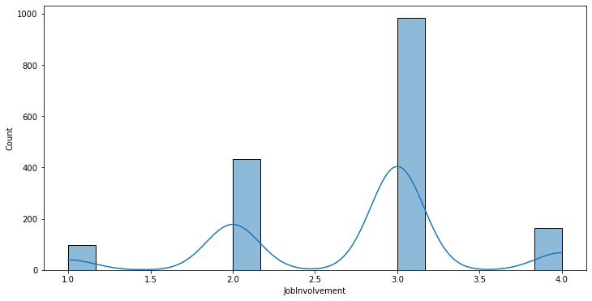

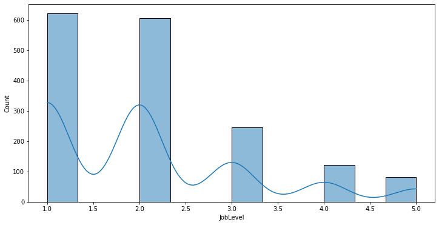

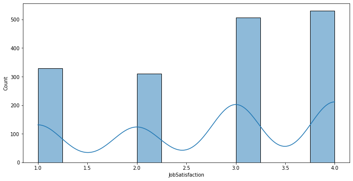

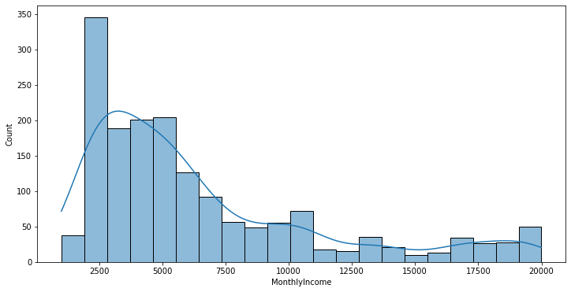

[14 more figures not shown]

```python
for col in num_cols:
    fig, ax = plt.subplots(1, figsize = (12, 6))
    sns.histplot(data = data_df[col], kde = True)
    plt.show()
```

# Milestone 3

### In Milestone 3, you will begin the process of selecting, building, and evaluating a model. You are required to train and evaluate at least one model in this milestone. Write step-by-step for performing each of these steps. You can use any methods/tools you think are most appropriate, but you should explain/justify why you are selecting the model(s) and evaluation metric(s) you choose. It is important to think about what type of model and metric makes sense for your problem. Again, do what makes the most sense for your project. Write a short overview/conclusion of the insights gained from your model building/evaluation.

### It is important to note that these milestones are meant to keep you on track for the final project submission. At any point, you can pivot or modify your project as needed based on what you discover. These milestones are not final versions; they are drafts of the many steps you need to complete along the way.

### As a reminder, Teams is a great place to discuss your project with your peers. Feel free to solicit feedback/input (without creating a group project!) and collaborate on your projects with your peers.

### Each milestone will build on top of each other, so make sure you do not fall behind. Submit Milestones 1-3 together. I recommend building your project milestones in a Jupyter Notebook, building upon one another. However, make sure it is clear where each milestone begins and ends.

Predict the model Accuracy

```python
from sklearn.linear_model import LogisticRegression
```

```python
# Splitting data
X_train, X_test, y_train, y_test = train_test_split(X, y,
                                                   test_size=.25,
                                                   random_state=42,
                                                   )
```

```python
logreg = LogisticRegression(penalty='l2',solver='liblinear', max_iter=250)
logreg.fit(X_train, y_train)
```

```
LogisticRegression(max_iter=250, solver='liblinear')
```

```python
y_pred = logreg.predict(X_test)
print("Model Accuracy:",round(logreg.score(X_test, y_test) * 100 , 0),"%")
```

```
Model Accuracy: 91.0 %
```

```python
## Display all the columns and rows so they can all be seen
pd.options.display.max_columns = None
pd.options.display.max_rows = None

## create a correlation matrix of the auto df and call is correlation_mat
correlation_matrix = X_train.corr()
correlation_matrix
```

|  | Age | DailyRate | DistanceFromHome | Education | EnvironmentSatisfaction | HourlyRate | JobInvolvement | JobLevel | JobSatisfaction | MonthlyIncome | MonthlyRate | NumCompaniesWorked | PercentSalaryHike | PerformanceRating | RelationshipSatisfaction | Shift | TotalWorkingYears | TrainingTimesLastYear | WorkLifeBalance | YearsAtCompany | YearsInCurrentRole | YearsSinceLastPromotion | YearsWithCurrManager | BusinessTravel_Travel_Frequently | BusinessTravel_Travel_Rarely | Department_Maternity | Department_Neurology | EducationField_Life Sciences | EducationField_Marketing | … |
| --- | --- | --- | --- | --- | --- | --- | --- | --- | --- | --- | --- | --- | --- | --- | --- | --- | --- | --- | --- | --- | --- | --- | --- | --- | --- | --- | --- | --- | --- | --- |
| Age | 1.00 | -0.01 | -0.02 | 0.21 | 0.02 | 0.02 | 0.05 | 0.50 | -0.01 | 0.50 | 0.03 | 0.27 | 0.04 | 0.02 | 0.04 | 0.03 | 0.68 | -0.04 | 0.01 | 0.32 | 0.22 | 0.21 | 0.22 | -0.04 | 0.04 | -0.04 | 0.10 | -0.03 | 0.06 | … |
| DailyRate | -0.01 | 1.00 | -0.02 | -0.03 | 0.01 | 0.04 | 0.04 | -0.01 | 0.03 | -0.00 | 0.01 | 0.02 | 0.02 | 0.02 | -0.01 | 0.06 | -0.02 | -0.02 | -0.02 | -0.04 | 0.01 | -0.04 | -0.05 | -0.02 | -0.00 | 0.02 | 0.01 | -0.02 | -0.05 | … |
| DistanceFromHome | -0.02 | -0.02 | 1.00 | 0.03 | -0.02 | 0.04 | 0.01 | -0.01 | -0.01 | -0.02 | 0.06 | -0.04 | 0.04 | 0.04 | 0.01 | 0.01 | -0.00 | -0.06 | -0.02 | 0.01 | 0.01 | 0.01 | 0.01 | -0.01 | -0.02 | 0.08 | -0.10 | -0.03 | 0.04 | … |
| Education | 0.21 | -0.03 | 0.03 | 1.00 | -0.02 | -0.00 | 0.05 | 0.09 | 0.02 | 0.09 | -0.02 | 0.11 | -0.01 | -0.01 | -0.00 | -0.01 | 0.14 | 0.02 | 0.00 | 0.05 | 0.05 | 0.04 | 0.05 | 0.00 | -0.01 | -0.02 | 0.02 | 0.01 | 0.05 | … |
| EnvironmentSatisfaction | 0.02 | 0.01 | -0.02 | -0.02 | 1.00 | -0.07 | 0.00 | 0.01 | -0.03 | 0.01 | 0.04 | 0.04 | -0.04 | -0.05 | -0.02 | -0.01 | 0.01 | -0.04 | 0.04 | 0.01 | -0.00 | 0.03 | 0.00 | -0.01 | 0.00 | -0.02 | 0.04 | -0.01 | 0.01 | … |
| HourlyRate | 0.02 | 0.04 | 0.04 | -0.00 | -0.07 | 1.00 | 0.06 | -0.00 | -0.09 | 0.00 | -0.02 | 0.01 | -0.01 | -0.00 | 0.01 | 0.05 | 0.01 | 0.01 | -0.02 | -0.01 | 0.00 | -0.04 | -0.00 | -0.02 | 0.03 | 0.03 | -0.04 | 0.05 | 0.04 | … |
| JobInvolvement | 0.05 | 0.04 | 0.01 | 0.05 | 0.00 | 0.06 | 1.00 | 0.00 | -0.07 | -0.01 | -0.01 | 0.05 | -0.01 | -0.01 | 0.03 | 0.01 | -0.00 | -0.04 | -0.02 | -0.01 | 0.03 | 0.01 | 0.04 | 0.03 | -0.01 | 0.02 | -0.01 | -0.01 | -0.02 | … |
| JobLevel | 0.50 | -0.01 | -0.01 | 0.09 | 0.01 | -0.00 | 0.00 | 1.00 | -0.01 | 0.95 | 0.05 | 0.14 | -0.01 | -0.00 | 0.01 | -0.00 | 0.78 | -0.03 | 0.05 | 0.53 | 0.38 | 0.34 | 0.38 | -0.03 | 0.03 | -0.25 | 0.18 | -0.04 | 0.11 | … |
| JobSatisfaction | -0.01 | 0.03 | -0.01 | 0.02 | -0.03 | -0.09 | -0.07 | -0.01 | 1.00 | -0.02 | 0.03 | -0.06 | 0.04 | 0.03 | -0.05 | 0.02 | -0.02 | -0.01 | -0.01 | 0.01 | 0.02 | -0.01 | -0.01 | 0.03 | -0.05 | -0.01 | -0.00 | 0.05 | -0.01 | … |
| MonthlyIncome | 0.50 | -0.00 | -0.02 | 0.09 | 0.01 | 0.00 | -0.01 | 0.95 | -0.02 | 1.00 | 0.05 | 0.16 | -0.00 | -0.00 | 0.02 | -0.01 | 0.77 | -0.03 | 0.05 | 0.51 | 0.36 | 0.33 | 0.35 | -0.04 | 0.04 | -0.22 | 0.21 | -0.03 | 0.07 | … |
| MonthlyRate | 0.03 | 0.01 | 0.06 | -0.02 | 0.04 | -0.02 | -0.01 | 0.05 | 0.03 | 0.05 | 1.00 | 0.05 | -0.01 | -0.02 | 0.01 | -0.04 | 0.05 | 0.00 | 0.01 | -0.03 | -0.03 | -0.02 | -0.05 | 0.00 | -0.00 | -0.04 | 0.03 | 0.03 | -0.01 | … |
| NumCompaniesWorked | 0.27 | 0.02 | -0.04 | 0.11 | 0.04 | 0.01 | 0.05 | 0.14 | -0.06 | 0.16 | 0.05 | 1.00 | 0.01 | -0.01 | 0.07 | 0.01 | 0.24 | -0.07 | 0.01 | -0.11 | -0.09 | -0.03 | -0.08 | -0.04 | 0.01 | -0.02 | 0.05 | -0.05 | 0.01 | … |
| PercentSalaryHike | 0.04 | 0.02 | 0.04 | -0.01 | -0.04 | -0.01 | -0.01 | -0.01 | 0.04 | -0.00 | -0.01 | 0.01 | 1.00 | 0.77 | -0.03 | 0.02 | 0.02 | -0.01 | -0.02 | -0.00 | 0.03 | 0.02 | 0.00 | -0.04 | 0.01 | 0.00 | -0.01 | -0.02 | 0.01 | … |
| PerformanceRating | 0.02 | 0.02 | 0.04 | -0.01 | -0.05 | -0.00 | -0.01 | -0.00 | 0.03 | -0.00 | -0.02 | -0.01 | 0.77 | 1.00 | -0.03 | 0.01 | 0.03 | -0.02 | -0.03 | 0.04 | 0.07 | 0.06 | 0.03 | -0.02 | 0.00 | -0.01 | 0.00 | -0.02 | 0.01 | … |
| RelationshipSatisfaction | 0.04 | -0.01 | 0.01 | -0.00 | -0.02 | 0.01 | 0.03 | 0.01 | -0.05 | 0.02 | 0.01 | 0.07 | -0.03 | -0.03 | 1.00 | -0.04 | 0.01 | 0.01 | 0.03 | 0.01 | -0.04 | 0.03 | -0.01 | 0.00 | -0.04 | -0.01 | 0.03 | -0.04 | -0.02 | … |
| Shift | 0.03 | 0.06 | 0.01 | -0.01 | -0.01 | 0.05 | 0.01 | -0.00 | 0.02 | -0.01 | -0.04 | 0.01 | 0.02 | 0.01 | -0.04 | 1.00 | 0.01 | 0.01 | -0.02 | 0.03 | 0.06 | 0.03 | 0.04 | 0.01 | -0.02 | 0.00 | -0.03 | -0.00 | 0.04 | … |
| TotalWorkingYears | 0.68 | -0.02 | -0.00 | 0.14 | 0.01 | 0.01 | -0.00 | 0.78 | -0.02 | 0.77 | 0.05 | 0.24 | 0.02 | 0.03 | 0.01 | 0.01 | 1.00 | -0.04 | 0.01 | 0.63 | 0.47 | 0.39 | 0.48 | -0.03 | 0.04 | -0.09 | 0.13 | -0.04 | 0.05 | … |
| TrainingTimesLastYear | -0.04 | -0.02 | -0.06 | 0.02 | -0.04 | 0.01 | -0.04 | -0.03 | -0.01 | -0.03 | 0.00 | -0.07 | -0.01 | -0.02 | 0.01 | 0.01 | -0.04 | 1.00 | 0.04 | -0.02 | -0.04 | -0.04 | -0.03 | 0.00 | 0.00 | -0.08 | 0.02 | -0.04 | -0.02 | … |
| WorkLifeBalance | 0.01 | -0.02 | -0.02 | 0.00 | 0.04 | -0.02 | -0.02 | 0.05 | -0.01 | 0.05 | 0.01 | 0.01 | -0.02 | -0.03 | 0.03 | -0.02 | 0.01 | 0.04 | 1.00 | 0.01 | 0.05 | 0.01 | 0.00 | 0.01 | -0.01 | -0.09 | 0.05 | -0.04 | 0.02 | … |
| YearsAtCompany | 0.32 | -0.04 | 0.01 | 0.05 | 0.01 | -0.01 | -0.01 | 0.53 | 0.01 | 0.51 | -0.03 | -0.11 | -0.00 | 0.04 | 0.01 | 0.03 | 0.63 | -0.02 | 0.01 | 1.00 | 0.76 | 0.61 | 0.77 | 0.02 | -0.01 | -0.08 | 0.07 | -0.03 | 0.05 | … |
| YearsInCurrentRole | 0.22 | 0.01 | 0.01 | 0.05 | -0.00 | 0.00 | 0.03 | 0.38 | 0.02 | 0.36 | -0.03 | -0.09 | 0.03 | 0.07 | -0.04 | 0.06 | 0.47 | -0.04 | 0.05 | 0.76 | 1.00 | 0.55 | 0.72 | -0.01 | -0.00 | -0.07 | 0.04 | 0.02 | 0.03 | … |
| YearsSinceLastPromotion | 0.21 | -0.04 | 0.01 | 0.04 | 0.03 | -0.04 | 0.01 | 0.34 | -0.01 | 0.33 | -0.02 | -0.03 | 0.02 | 0.06 | 0.03 | 0.03 | 0.39 | -0.04 | 0.01 | 0.61 | 0.55 | 1.00 | 0.50 | 0.02 | -0.02 | -0.05 | 0.06 | -0.04 | 0.00 | … |
| YearsWithCurrManager | 0.22 | -0.05 | 0.01 | 0.05 | 0.00 | -0.00 | 0.04 | 0.38 | -0.01 | 0.35 | -0.05 | -0.08 | 0.00 | 0.03 | -0.01 | 0.04 | 0.48 | -0.03 | 0.00 | 0.77 | 0.72 | 0.50 | 1.00 | 0.01 | -0.01 | -0.07 | 0.04 | -0.01 | 0.05 | … |
| BusinessTravel_Travel_Frequently | -0.04 | -0.02 | -0.01 | 0.00 | -0.01 | -0.02 | 0.03 | -0.03 | 0.03 | -0.04 | 0.00 | -0.04 | -0.04 | -0.02 | 0.00 | 0.01 | -0.03 | 0.00 | 0.01 | 0.02 | -0.01 | 0.02 | 0.01 | 1.00 | -0.77 | -0.00 | -0.00 | 0.02 | -0.01 | … |
| BusinessTravel_Travel_Rarely | 0.04 | -0.00 | -0.02 | -0.01 | 0.00 | 0.03 | -0.01 | 0.03 | -0.05 | 0.04 | -0.00 | 0.01 | 0.01 | 0.00 | -0.04 | -0.02 | 0.04 | 0.00 | -0.01 | -0.01 | -0.00 | -0.02 | -0.01 | -0.77 | 1.00 | 0.03 | -0.03 | -0.01 | 0.03 | … |
| Department_Maternity | -0.04 | 0.02 | 0.08 | -0.02 | -0.02 | 0.03 | 0.02 | -0.25 | -0.01 | -0.22 | -0.04 | -0.02 | 0.00 | -0.01 | -0.01 | 0.00 | -0.09 | -0.08 | -0.09 | -0.08 | -0.07 | -0.05 | -0.07 | -0.00 | 0.03 | 1.00 | -0.48 | 0.10 | -0.34 | … |
| Department_Neurology | 0.10 | 0.01 | -0.10 | 0.02 | 0.04 | -0.04 | -0.01 | 0.18 | -0.00 | 0.21 | 0.03 | 0.05 | -0.01 | 0.00 | 0.03 | -0.03 | 0.13 | 0.02 | 0.05 | 0.07 | 0.04 | 0.06 | 0.04 | -0.00 | -0.03 | -0.48 | 1.00 | -0.00 | -0.18 | … |
| EducationField_Life Sciences | -0.03 | -0.02 | -0.03 | 0.01 | -0.01 | 0.05 | -0.01 | -0.04 | 0.05 | -0.03 | 0.03 | -0.05 | -0.02 | -0.02 | -0.04 | -0.00 | -0.04 | -0.04 | -0.04 | -0.03 | 0.02 | -0.04 | -0.01 | 0.02 | -0.01 | 0.10 | -0.00 | 1.00 | -0.30 | … |
| EducationField_Marketing | 0.06 | -0.05 | 0.04 | 0.05 | 0.01 | 0.04 | -0.02 | 0.11 | -0.01 | 0.07 | -0.01 | 0.01 | 0.01 | 0.01 | -0.02 | 0.04 | 0.05 | -0.02 | 0.02 | 0.05 | 0.03 | 0.00 | 0.05 | -0.01 | 0.03 | -0.34 | -0.18 | -0.30 | 1.00 | … |
| EducationField_Medical | 0.01 | 0.04 | 0.01 | -0.09 | -0.05 | -0.03 | 0.04 | 0.00 | -0.03 | 0.02 | -0.01 | 0.04 | 0.02 | 0.02 | 0.06 | 0.00 | 0.03 | 0.06 | -0.00 | 0.02 | -0.03 | 0.05 | -0.02 | 0.00 | -0.02 | 0.10 | 0.04 | -0.57 | -0.24 | … |
| EducationField_Other | -0.03 | 0.02 | -0.01 | 0.06 | 0.07 | -0.03 | -0.02 | -0.03 | -0.01 | -0.04 | -0.06 | 0.02 | 0.05 | 0.02 | -0.03 | -0.04 | -0.04 | 0.01 | 0.03 | -0.05 | -0.04 | -0.04 | -0.01 | -0.01 | 0.02 | 0.06 | 0.01 | -0.21 | -0.09 | … |
| EducationField_Technical Degree | -0.02 | 0.04 | -0.00 | -0.01 | 0.03 | -0.04 | -0.01 | -0.04 | -0.03 | -0.04 | 0.01 | -0.02 | -0.02 | -0.01 | -0.00 | -0.02 | -0.02 | 0.00 | 0.03 | -0.01 | 0.02 | 0.02 | 0.01 | -0.02 | 0.01 | 0.05 | 0.00 | -0.26 | -0.11 | … |
| Gender_Male | -0.03 | 0.00 | 0.01 | -0.04 | -0.01 | -0.03 | 0.00 | -0.03 | 0.04 | -0.02 | -0.02 | -0.06 | 0.01 | -0.01 | 0.03 | 0.01 | -0.05 | -0.03 | -0.00 | -0.03 | -0.03 | -0.03 | -0.03 | -0.03 | -0.03 | 0.06 | 0.00 | 0.01 | -0.04 | … |
| JobRole_Administrative | 0.25 | -0.04 | 0.01 | 0.09 | 0.01 | 0.01 | 0.00 | 0.52 | -0.01 | 0.59 | 0.03 | 0.09 | -0.01 | -0.00 | -0.01 | -0.02 | 0.43 | -0.06 | 0.04 | 0.29 | 0.17 | 0.12 | 0.17 | -0.06 | 0.07 | -0.02 | 0.02 | -0.00 | 0.00 | … |
| JobRole_Nurse | -0.09 | -0.01 | 0.04 | 0.01 | 0.00 | 0.00 | -0.02 | -0.13 | 0.02 | -0.19 | -0.01 | -0.03 | -0.05 | -0.04 | -0.03 | 0.04 | -0.13 | 0.06 | -0.01 | -0.05 | -0.00 | 0.00 | -0.00 | -0.00 | -0.02 | -0.01 | -0.26 | 0.02 | 0.18 | … |
| JobRole_Other | -0.10 | 0.04 | -0.03 | -0.04 | -0.03 | -0.01 | 0.04 | -0.29 | -0.03 | -0.23 | -0.02 | -0.04 | 0.03 | 0.02 | 0.03 | -0.03 | -0.18 | -0.03 | -0.02 | -0.15 | -0.14 | -0.08 | -0.15 | 0.04 | -0.00 | 0.07 | 0.14 | -0.03 | -0.14 | … |
| JobRole_Therapist | 0.07 | -0.01 | -0.01 | -0.03 | 0.04 | -0.00 | -0.03 | 0.15 | 0.01 | 0.10 | 0.02 | 0.03 | 0.03 | 0.01 | -0.00 | -0.00 | 0.09 | -0.00 | 0.02 | 0.02 | 0.05 | 0.00 | 0.07 | -0.00 | -0.01 | -0.08 | 0.20 | 0.03 | -0.08 | … |
| MaritalStatus_Married | 0.10 | 0.02 | 0.01 | 0.01 | -0.03 | 0.05 | 0.05 | 0.05 | -0.02 | 0.05 | -0.02 | -0.05 | 0.02 | 0.01 | -0.04 | 0.20 | 0.05 | -0.04 | 0.01 | 0.06 | 0.08 | 0.05 | 0.04 | -0.02 | 0.05 | -0.05 | 0.04 | -0.02 | 0.06 | … |
| MaritalStatus_Single | -0.11 | -0.09 | -0.01 | 0.01 | 0.00 | -0.04 | -0.05 | -0.07 | 0.02 | -0.07 | 0.03 | 0.01 | 0.02 | 0.02 | 0.02 | -0.63 | -0.07 | 0.03 | 0.01 | -0.07 | -0.09 | -0.03 | -0.05 | 0.02 | -0.01 | 0.01 | -0.03 | 0.03 | -0.05 | … |
| OverTime_Yes | 0.04 | 0.03 | 0.02 | -0.04 | 0.09 | -0.02 | -0.03 | 0.02 | 0.04 | 0.03 | -0.00 | 0.00 | -0.01 | -0.00 | 0.04 | 0.01 | 0.03 | -0.05 | -0.02 | -0.00 | -0.02 | -0.03 | -0.04 | 0.06 | -0.01 | 0.06 | -0.04 | -0.01 | 0.03 | … |

```python
X.describe()
```

|  | Age | DailyRate | DistanceFromHome | Education | EnvironmentSatisfaction | HourlyRate | JobInvolvement | JobLevel | JobSatisfaction | MonthlyIncome | MonthlyRate | NumCompaniesWorked | PercentSalaryHike | PerformanceRating | RelationshipSatisfaction | Shift | TotalWorkingYears | TrainingTimesLastYear | WorkLifeBalance | YearsAtCompany | YearsInCurrentRole | YearsSinceLastPromotion | YearsWithCurrManager | BusinessTravel_Travel_Frequently | BusinessTravel_Travel_Rarely | Department_Maternity | Department_Neurology | EducationField_Life Sciences | EducationField_Marketing | … |
| --- | --- | --- | --- | --- | --- | --- | --- | --- | --- | --- | --- | --- | --- | --- | --- | --- | --- | --- | --- | --- | --- | --- | --- | --- | --- | --- | --- | --- | --- | --- |
| count | 1676.00 | 1676.00 | 1676.00 | 1676.00 | 1676.00 | 1676.00 | 1676.00 | 1676.00 | 1676.00 | 1676.00 | 1676.00 | 1676.00 | 1676.00 | 1676.00 | 1676.00 | 1676.00 | 1676.00 | 1676.00 | 1676.00 | 1676.00 | 1676.00 | 1676.00 | 1676.00 | 1676.00 | 1676.00 | 1676.00 | 1676.00 | 1676.00 | 1676.00 | … |
| mean | 36.87 | 800.56 | 9.22 | 2.91 | 2.71 | 65.47 | 2.72 | 2.07 | 2.74 | 6516.51 | 14287.02 | 2.66 | 15.20 | 3.15 | 2.72 | 0.81 | 11.34 | 2.81 | 2.77 | 7.03 | 4.26 | 2.20 | 4.14 | 0.19 | 0.71 | 0.47 | 0.21 | 0.42 | 0.11 | … |
| std | 9.13 | 401.59 | 8.16 | 1.03 | 1.10 | 20.21 | 0.71 | 1.11 | 1.10 | 4728.46 | 7138.86 | 2.48 | 3.65 | 0.36 | 1.08 | 0.86 | 7.83 | 1.29 | 0.70 | 6.10 | 3.63 | 3.23 | 3.56 | 0.39 | 0.46 | 0.50 | 0.41 | 0.49 | 0.32 | … |
| min | 18.00 | 102.00 | 1.00 | 1.00 | 1.00 | 30.00 | 1.00 | 1.00 | 1.00 | 1009.00 | 2094.00 | 0.00 | 11.00 | 3.00 | 1.00 | 0.00 | 0.00 | 0.00 | 1.00 | 0.00 | 0.00 | 0.00 | 0.00 | 0.00 | 0.00 | 0.00 | 0.00 | 0.00 | 0.00 | … |
| 25% | 30.00 | 465.00 | 2.00 | 2.00 | 2.00 | 48.00 | 2.00 | 1.00 | 2.00 | 2928.25 | 7993.00 | 1.00 | 12.00 | 3.00 | 2.00 | 0.00 | 6.00 | 2.00 | 2.00 | 3.00 | 2.00 | 0.00 | 2.00 | 0.00 | 0.00 | 0.00 | 0.00 | 0.00 | 0.00 | … |
| 50% | 36.00 | 796.50 | 7.00 | 3.00 | 3.00 | 65.50 | 3.00 | 2.00 | 3.00 | 4899.00 | 14269.50 | 2.00 | 14.00 | 3.00 | 3.00 | 1.00 | 10.00 | 3.00 | 3.00 | 5.00 | 3.00 | 1.00 | 3.00 | 0.00 | 1.00 | 0.00 | 0.00 | 0.00 | 0.00 | … |
| 75% | 43.00 | 1157.00 | 14.00 | 4.00 | 4.00 | 83.00 | 3.00 | 3.00 | 4.00 | 8380.25 | 20462.00 | 4.00 | 18.00 | 3.00 | 4.00 | 1.00 | 15.00 | 3.00 | 3.00 | 10.00 | 7.00 | 3.00 | 7.00 | 0.00 | 1.00 | 1.00 | 0.00 | 1.00 | 0.00 | … |
| max | 60.00 | 1499.00 | 29.00 | 5.00 | 4.00 | 100.00 | 4.00 | 5.00 | 4.00 | 19999.00 | 26999.00 | 9.00 | 25.00 | 4.00 | 4.00 | 3.00 | 40.00 | 6.00 | 4.00 | 40.00 | 18.00 | 15.00 | 17.00 | 1.00 | 1.00 | 1.00 | 1.00 | 1.00 | 1.00 | … |

```python
pd.options.display.float_format = '{:.2f}'.format
y.describe()
```

```
count   1676.00
mean       0.12
std        0.32
min        0.00
25%        0.00
50%        0.00
75%        0.00
max        1.00
Name: Attrition, dtype: float64
```

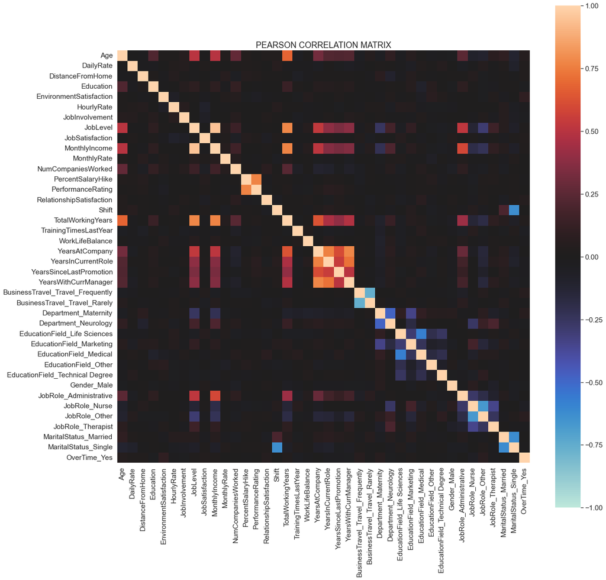

```python
## look for multicollinearity of features
fig, ax = plt.subplots(figsize=(20, 20))

sns.heatmap(X_train.corr(), center=0,
           vmin=-1, vmax=1,  square=True)

# title
plt.title('PEARSON CORRELATION MATRIX', fontsize=18)

plt.show()
```

```python
df_correlations = X_train.corr().abs().stack().reset_index().sort_values(0, ascending=False)

# zip the variable name columns in a new column named "pairs"
df_correlations['pairs'] = list(zip(df_correlations.level_0, df_correlations.level_1))

# set index to pairs
df_correlations.set_index(['pairs'], inplace = True)

# rename our results column to correlation
df_correlations.rename(columns={0: "correlation"}, inplace=True)

# Drop 1:1 correlations to get rid of self pairs
df_correlations.drop(df_correlations[df_correlations['correlation'] == 1.000000].index, inplace=True)

# view pairs above 75% correlation and below 90% correlation (engineered features will correlate with each other above 95%)
df_correlations[(df_correlations.correlation>.75) & (df_correlations.correlation<.95)]
```

| pairs | level_0 | level_1 | correlation |
| --- | --- | --- | --- |
| (TotalWorkingYears, JobLevel) | TotalWorkingYears | JobLevel | 0.78 |
| (JobLevel, TotalWorkingYears) | JobLevel | TotalWorkingYears | 0.78 |
| (YearsAtCompany, YearsWithCurrManager) | YearsAtCompany | YearsWithCurrManager | 0.77 |
| (YearsWithCurrManager, YearsAtCompany) | YearsWithCurrManager | YearsAtCompany | 0.77 |
| (MonthlyIncome, TotalWorkingYears) | MonthlyIncome | TotalWorkingYears | 0.77 |
| (TotalWorkingYears, MonthlyIncome) | TotalWorkingYears | MonthlyIncome | 0.77 |
| (PercentSalaryHike, PerformanceRating) | PercentSalaryHike | PerformanceRating | 0.77 |
| (PerformanceRating, PercentSalaryHike) | PerformanceRating | PercentSalaryHike | 0.77 |
| (BusinessTravel_Travel_Frequently, BusinessTravel_Travel_Rarely) | BusinessTravel_Travel_Frequently | BusinessTravel_Travel_Rarely | 0.77 |
| (BusinessTravel_Travel_Rarely, BusinessTravel_Travel_Frequently) | BusinessTravel_Travel_Rarely | BusinessTravel_Travel_Frequently | 0.77 |
| (YearsAtCompany, YearsInCurrentRole) | YearsAtCompany | YearsInCurrentRole | 0.76 |
| (YearsInCurrentRole, YearsAtCompany) | YearsInCurrentRole | YearsAtCompany | 0.76 |

```python
df_correlations = X_train.corr().abs().stack().reset_index().sort_values(0, ascending=False)
df_correlations.loc[df_correlations['level_0'] == 'TotalWorkingYears'].sort_values(0, ascending=False)
```

|  | level_0 | level_1 | 0 |
| --- | --- | --- | --- |
| 656 | TotalWorkingYears | TotalWorkingYears | 1.00 |
| 647 | TotalWorkingYears | JobLevel | 0.78 |
| 649 | TotalWorkingYears | MonthlyIncome | 0.77 |
| 640 | TotalWorkingYears | Age | 0.68 |
| 659 | TotalWorkingYears | YearsAtCompany | 0.63 |
| 662 | TotalWorkingYears | YearsWithCurrManager | 0.48 |
| 660 | TotalWorkingYears | YearsInCurrentRole | 0.47 |
| 673 | TotalWorkingYears | JobRole_Administrative | 0.43 |
| 661 | TotalWorkingYears | YearsSinceLastPromotion | 0.39 |
| 651 | TotalWorkingYears | NumCompaniesWorked | 0.24 |
| 675 | TotalWorkingYears | JobRole_Other | 0.18 |
| 643 | TotalWorkingYears | Education | 0.14 |
| 674 | TotalWorkingYears | JobRole_Nurse | 0.13 |
| 666 | TotalWorkingYears | Department_Neurology | 0.13 |
| 665 | TotalWorkingYears | Department_Maternity | 0.09 |
| 676 | TotalWorkingYears | JobRole_Therapist | 0.09 |
| 678 | TotalWorkingYears | MaritalStatus_Single | 0.07 |
| 668 | TotalWorkingYears | EducationField_Marketing | 0.05 |
| 672 | TotalWorkingYears | Gender_Male | 0.05 |
| 677 | TotalWorkingYears | MaritalStatus_Married | 0.05 |
| 650 | TotalWorkingYears | MonthlyRate | 0.05 |
| 664 | TotalWorkingYears | BusinessTravel_Travel_Rarely | 0.04 |
| 667 | TotalWorkingYears | EducationField_Life Sciences | 0.04 |
| 657 | TotalWorkingYears | TrainingTimesLastYear | 0.04 |
| 670 | TotalWorkingYears | EducationField_Other | 0.04 |
| 679 | TotalWorkingYears | OverTime_Yes | 0.03 |
| 653 | TotalWorkingYears | PerformanceRating | 0.03 |
| 669 | TotalWorkingYears | EducationField_Medical | 0.03 |
| 663 | TotalWorkingYears | BusinessTravel_Travel_Frequently | 0.03 |
| 671 | TotalWorkingYears | EducationField_Technical Degree | 0.02 |
| 641 | TotalWorkingYears | DailyRate | 0.02 |
| 648 | TotalWorkingYears | JobSatisfaction | 0.02 |
| 652 | TotalWorkingYears | PercentSalaryHike | 0.02 |
| 658 | TotalWorkingYears | WorkLifeBalance | 0.01 |
| 645 | TotalWorkingYears | HourlyRate | 0.01 |
| 654 | TotalWorkingYears | RelationshipSatisfaction | 0.01 |
| 655 | TotalWorkingYears | Shift | 0.01 |
| 644 | TotalWorkingYears | EnvironmentSatisfaction | 0.01 |
| 646 | TotalWorkingYears | JobInvolvement | 0.00 |
| 642 | TotalWorkingYears | DistanceFromHome | 0.00 |

### Observation:

Total Years worked has a high positive corelation with the following:

- Job Level
- Monthly Income
- Years At Company

This means that for the number of years worked within the a company, there is a high likelihood these individuals are paid well, and have spent a long while in a prestigious career within their company and are less likely to leave.

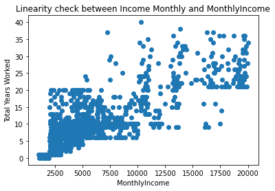

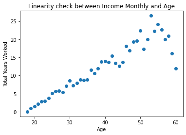

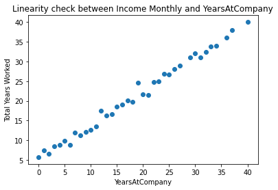

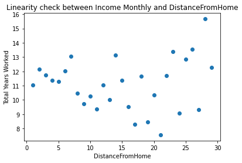

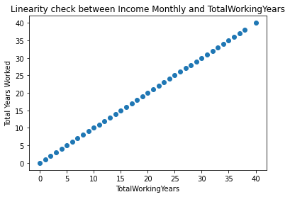

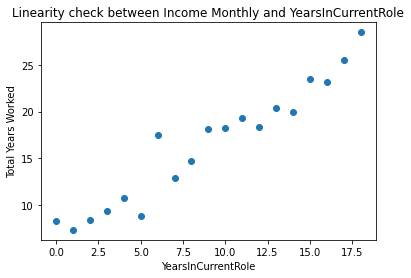

```python
## Creating linear chart between TotalYearsWorked and couple of constant variables available in dataset
## Among various features available in the dataset,
## I have chosen below constant variables for plotting which are most useful compared to other features
linearCols = [ 'MonthlyIncome', 'Age', 'YearsAtCompany', 'DistanceFromHome', 'TotalWorkingYears', 'YearsInCurrentRole']

## Plotting linear graph between Price and vriables present in the above list
for col in linearCols:
    lat_changes = X_train.groupby(col)['TotalWorkingYears'].mean()
    plt.scatter(lat_changes.index, lat_changes)
    plt.title("Linearity check between Income Monthly and "+ col)
    plt.xlabel(col)
    plt.ylabel('Total Years Worked')
    plt.show()
```

### RandomForest Classification

```python
from sklearn.ensemble import RandomForestClassifier
rd = RandomForestClassifier()
```

```python
rd.fit(X_train,y_train)
```

```
RandomForestClassifier()
```

```python
y_pred = rd.predict(X_test)
```

```python
print(f'RandomForest Classification Score:  {accuracy_score(y_test, y_pred)}')
```

```
RandomForest Classification Score:  0.8902147971360382
```

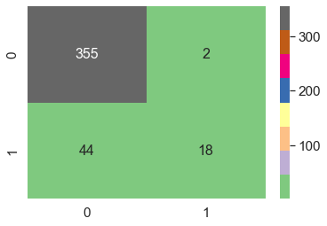

```python
cm = confusion_matrix(y_test, y_pred)
sns.set(font_scale=1.4)
sns.heatmap(cm, annot=True, annot_kws={"size": 16}, fmt="d", cmap='Accent')
plt.show()
```